# Linear_model_with_contrast

Xuening

4/16/2020

## Load data and EDA

```r
url <- "https://raw.githubusercontent.com/genomicsclass/dagdata/master/inst/extdata/spider_wolff_gorb_2013.csv"
filename <- "spider.csv"
if (!file.exists(filename)) download.file(url, filename)
spider <- read.csv(filename, skip=1)
table(spider$leg,spider$type)
```

```
##
##      pull push
##   L1   34   34
##   L2   15   15
##   L3   52   52
##   L4   40   40
```

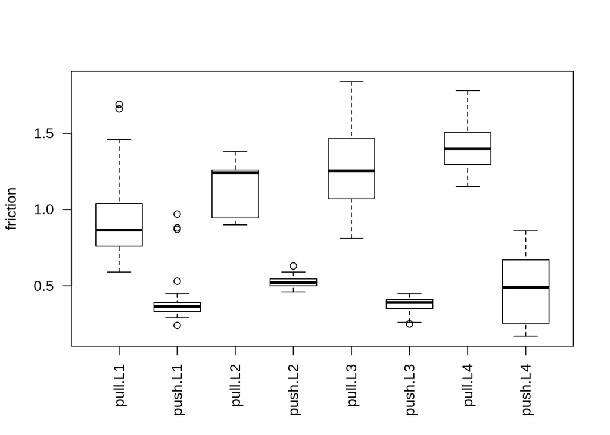

```r
boxplot(spider$friction~spider$type*spider$leg,las=2,xlab="",ylab="friction") # las=2 give vertical x labels
```

## Fit a linear model

Design a model matrix that records the condition of both push/pull and leg number.

```r
X <- model.matrix(~type+leg+type:leg,data=spider)
head(X)
```

```
##   (Intercept) typepush legL2 legL3 legL4 typepush:legL2 typepush:legL3
## 1           1        0     0     0     0              0              0
## 2           1        0     0     0     0              0              0
## 3           1        0     0     0     0              0              0
## 4           1        0     0     0     0              0              0
## 5           1        0     0     0     0              0              0
## 6           1        0     0     0     0              0              0
##   typepush:legL4
## 1              0
## 2              0
## 3              0
## 4              0
## 5              0
## 6              0
```

```r
colSums(X)
```

```
##    (Intercept)       typepush          legL2          legL3          legL4
##            282            141             30            104             80
## typepush:legL2 typepush:legL3 typepush:legL4
##             15             52             40
```

The column sum corresponds with the table. Now fit a linear model.

```r
fit <- lm(friction~type*leg,data=spider)
summary(fit)
```

```
##
## Call:
## lm(formula = friction ~ type * leg, data = spider)
##
## Residuals:
##      Min       1Q   Median       3Q      Max
## -0.46385 -0.10735 -0.01111  0.07848  0.76853
##
## Coefficients:
##                Estimate Std. Error t value Pr(>|t|)
## (Intercept)     0.92147    0.03266  28.215  < 2e-16 ***
## typepush       -0.51412    0.04619 -11.131  < 2e-16 ***
## legL2           0.22386    0.05903   3.792 0.000184 ***
## legL3           0.35238    0.04200   8.390 2.62e-15 ***
## legL4           0.47928    0.04442  10.789  < 2e-16 ***
## typepush:legL2 -0.10388    0.08348  -1.244 0.214409
## typepush:legL3 -0.38377    0.05940  -6.461 4.73e-10 ***
## typepush:legL4 -0.39588    0.06282  -6.302 1.17e-09 ***
## ---
## Signif. codes:  0 '***' 0.001 '**' 0.01 '*' 0.05 '.' 0.1 ' ' 1
##
## Residual standard error: 0.1904 on 274 degrees of freedom
## Multiple R-squared:  0.8279, Adjusted R-squared:  0.8235
## F-statistic: 188.3 on 7 and 274 DF,  p-value: < 2.2e-16
```

```r
coefs <- coef(fit)
coefs
```

```
##    (Intercept)       typepush          legL2          legL3          legL4
##      0.9214706     -0.5141176      0.2238627      0.3523756      0.4792794
## typepush:legL2 typepush:legL3 typepush:legL4
##     -0.1038824     -0.3837670     -0.3958824
```

## Do L2 and L3 have same friction when pulling?

The average friction of L2 pulling is `coefs["(Intercept)"]`+`coefs["legL2"]`. The average friction of L3 pulling is `coefs["(Intercept)"]`+`coefs["legL3"]`. Let’s verify this:

```r
coefs["(Intercept)"]+coefs["legL2"]
```

```
## (Intercept)
##    1.145333
```

```r
coefs["(Intercept)"]+coefs["legL3"]
```

```
## (Intercept)
##    1.273846
```

```r
library(dplyr)
spider %>% group_by(type, leg) %>% summarize(mean_val=mean(friction))
```

```
## # A tibble: 8 x 3
## # Groups:   type [2]
##   type  leg   mean_val
##   <fct> <fct>    <dbl>
## 1 pull  L1       0.921
## 2 pull  L2       1.15
## 3 pull  L3       1.27
## 4 pull  L4       1.40
## 5 push  L1       0.407
## 6 push  L2       0.527
## 7 push  L3       0.376
## 8 push  L4       0.491
```

So the question equals to: is (`coefs["(Intercept)"]`+`coefs["legL2"]`)-(`coefs["(Intercept)"]`+`coefs["legL3"]`) significantly different from $0$? Since `coefs["(Intercept)"]` cancel out, we are asking whether `coefs["legL2"]`-`coefs["legL3"]` significantly different from $0$.

Here contrast matrix come into play. We can write `coefs` as a column vector $\hat\beta$. Design contrast matrix as $c=[0,0,1,-1,0,0,0,0]^T$, and we find
$$c\hat\beta=\hat\beta_3-\hat\beta_4$$
Other good properties:
$$E[\hat\beta_3-\hat\beta_4]=E[c^T\hat\beta]=c^TE[\hat\beta]=c^T\beta=\beta_3-\beta_4$$
$$Var[\hat\beta_3-\hat\beta_4]=Var[c^T\hat\beta]=c^TVar(\hat\beta)c=\sigma^2c^T(X^TX)^{-1}c$$

Let’s calculate.

```r
coefs["legL2"]-coefs["legL3"]
```

```
##      legL2
## -0.1285128
```

```r
# calculate standard error
# 1. estimate variance of beta
var_beta <- sum(fit$residuals^2)/(nrow(X)-ncol(X)) * solve(crossprod(X))
head(var_beta)
```

```
##                 (Intercept)     typepush        legL2        legL3        legL4
## (Intercept)     0.001066637 -0.001066637 -0.001066637 -0.001066637 -0.001066637
## typepush       -0.001066637  0.002133274  0.001066637  0.001066637  0.001066637
## legL2          -0.001066637  0.001066637  0.003484348  0.001066637  0.001066637
## legL3          -0.001066637  0.001066637  0.001066637  0.001764054  0.001066637
## legL4          -0.001066637  0.001066637  0.001066637  0.001066637  0.001973279
## typepush:legL2  0.001066637 -0.002133274 -0.003484348 -0.001066637 -0.001066637
##                typepush:legL2 typepush:legL3 typepush:legL4
## (Intercept)       0.001066637    0.001066637    0.001066637
## typepush         -0.002133274   -0.002133274   -0.002133274
## legL2            -0.003484348   -0.001066637   -0.001066637
## legL3            -0.001066637   -0.001764054   -0.001066637
## legL4            -0.001066637   -0.001066637   -0.001973279
## typepush:legL2    0.006968697    0.002133274    0.002133274
```

One thing to clarify: `var_beta` is the variance-covariance matrix of all the estimated parameters.

```r
c <- matrix(c(0,0,1,-1,0,0,0,0))
se <- sqrt(t(c) %*% var_beta %*% c)
se
```

```
##            [,1]
## [1,] 0.05581333
```

Then t value:

```r
tval <- (coefs["legL2"]-coefs["legL3"])/se
tval
```

```
##           [,1]
## [1,] -2.302547
```

Then p value:

```r
2*pt(-abs(tval),nrow(X)-ncol(X))
```

```
##            [,1]
## [1,] 0.02205394
```

If $\alpha=0.05$ then we can conclude that L2 and L3 have significant difference in friction when pulling.

We can also do the analysis above using lackage `contrast`.

```r
library(contrast)
L2pull_L3pull <- contrast(fit,
                          list(type="pull",leg="L2"),
                          list(type="pull",leg="L3"))
L2pull_L3pull
```

```
## lm model parameter contrast
##
##    Contrast       S.E.      Lower       Upper    t  df Pr(>|t|)
##  -0.1285128 0.05581333 -0.2383903 -0.01863537 -2.3 274   0.0221
```

## Does push vs. pull have same effect on L2?

```r
L2push_L2pull <- contrast(fit,
                          list(type="push",leg="L2"),
                          list(type="pull",leg="L2"))
L2push_L2pull
```

```
## lm model parameter contrast
##
##  Contrast      S.E.      Lower      Upper     t  df Pr(>|t|)
##    -0.618 0.0695372 -0.7548951 -0.4811049 -8.89 274        0
```

So push and pull have significantly different effects on L2.

This question equals to: does (`coefs["(Intercept)"]`+`coefs["legL2"]`+`coefs["typepush"]`+`coefs["typepush:legL2"]`) significantly different from (`coefs["(Intercept)"]`+`coefs["legL2"]`). After cancelling out, only `coefs["typepush"]`+`coefs["typepush:legL2"]` is left. Let’s try.

```r
coefs["typepush"]+coefs["typepush:legL2"]
```

```
## typepush
##   -0.618
```

## Does push vs. pull have equal effects on L1 and L2?

Push-pull difference on L1 is (`coefs["(Intercept)"]`+`coefs["typepush"]`)-`coefs["(Intercept)"]`=`coefs["typepush"]`.

Push-pull difference on L2 is (`coefs["(Intercept)"]`+`coefs["typepush"]`+`coefs["legL2"]`+`coefs["typepush:legL2"]`)-(`coefs["(Intercept)"]`+`coefs["legL2"]`)=`coefs["typepush"]`+`coefs["typepush:legL2"]`.

The difference between difference is `coefs["typepush:legL2"]`. So let’s see its t value and p value.

```r
summary(fit)$coefficients
```

```
##                  Estimate Std. Error    t value     Pr(>|t|)
## (Intercept)     0.9214706 0.03265941  28.214549 4.889128e-83
## typepush       -0.5141176 0.04618738 -11.131127 5.433806e-24
## legL2           0.2238627 0.05902837   3.792460 1.835384e-04
## legL3           0.3523756 0.04200064   8.389766 2.616600e-15
## legL4           0.4792794 0.04442160  10.789331 7.504378e-23
## typepush:legL2 -0.1038824 0.08347872  -1.244417 2.144095e-01
## typepush:legL3 -0.3837670 0.05939788  -6.460954 4.733581e-10
## typepush:legL4 -0.3958824 0.06282163  -6.301688 1.170637e-09
```

The p value is 0.2144, so push vs. pull effects on L1 and L2 have no significant difference.

## Does push vs. pull have equal effects on L2 and L3?

Push-pull difference on L2 is (`coefs["(Intercept)"]`+`coefs["typepush"]`+`coefs["legL2"]`+`coefs["typepush:legL2"]`)-(`coefs["(Intercept)"]`+`coefs["legL2"]`)=`coefs["typepush"]`+`coefs["typepush:legL2"]`.

Push-pull difference on L3 is (`coefs["(Intercept)"]`+`coefs["typepush"]`+`coefs["legL3"]`+`coefs["typepush:legL3"]`)-(`coefs["(Intercept)"]`+`coefs["legL3"]`)=`coefs["typepush"]`+`coefs["typepush:legL3"]`.

The difference between the difference is `coefs["typepush:legL3"]`-`coefs["typepush:legL2"]`

Let validate this.

```r
library(multcomp)
C <- matrix(c(0,0,0,0,0,-1,1,0), 1)
L3vsL2interaction <- glht(fit, linfct=C)
summary(L3vsL2interaction)
```

```
##
##   Simultaneous Tests for General Linear Hypotheses
##
## Fit: lm(formula = friction ~ type * leg, data = spider)
##
## Linear Hypotheses:
##        Estimate Std. Error t value Pr(>|t|)
## 1 == 0 -0.27988    0.07893  -3.546  0.00046 ***
## ---
## Signif. codes:  0 '***' 0.001 '**' 0.01 '*' 0.05 '.' 0.1 ' ' 1
## (Adjusted p values reported -- single-step method)
```

```r
coefs["typepush:legL3"]-coefs["typepush:legL2"]
```

```
## typepush:legL3
##     -0.2798846
```

And the answer: push vs. pull have significantly different effects on L2 and L3.

## Model matrix without intercept

```r
spider$group <- factor(paste0(spider$leg, spider$type))
X <- model.matrix(~ 0 + group, data=spider)
head(X)
```

```
##   groupL1pull groupL1push groupL2pull groupL2push groupL3pull groupL3push
## 1           1           0           0           0           0           0
## 2           1           0           0           0           0           0
## 3           1           0           0           0           0           0
## 4           1           0           0           0           0           0
## 5           1           0           0           0           0           0
## 6           1           0           0           0           0           0
##   groupL4pull groupL4push
## 1           0           0
## 2           0           0
## 3           0           0
## 4           0           0
## 5           0           0
## 6           0           0
```

```r
fitG <- lm(friction ~ 0 + group, data=spider)
summary(fitG)
```

```
##
## Call:
## lm(formula = friction ~ 0 + group, data = spider)
##
## Residuals:
##      Min       1Q   Median       3Q      Max
## -0.46385 -0.10735 -0.01111  0.07848  0.76853
##
## Coefficients:
##             Estimate Std. Error t value Pr(>|t|)
## groupL1pull  0.92147    0.03266   28.21   <2e-16 ***
## groupL1push  0.40735    0.03266   12.47   <2e-16 ***
## groupL2pull  1.14533    0.04917   23.29   <2e-16 ***
## groupL2push  0.52733    0.04917   10.72   <2e-16 ***
## groupL3pull  1.27385    0.02641   48.24   <2e-16 ***
## groupL3push  0.37596    0.02641   14.24   <2e-16 ***
## groupL4pull  1.40075    0.03011   46.52   <2e-16 ***
## groupL4push  0.49075    0.03011   16.30   <2e-16 ***
## ---
## Signif. codes:  0 '***' 0.001 '**' 0.01 '*' 0.05 '.' 0.1 ' ' 1
##
## Residual standard error: 0.1904 on 274 degrees of freedom
## Multiple R-squared:   0.96,  Adjusted R-squared:  0.9588
## F-statistic:   821 on 8 and 274 DF,  p-value: < 2.2e-16
```

```r
coefs <- coef(fitG)
coefs
```

```
## groupL1pull groupL1push groupL2pull groupL2push groupL3pull groupL3push
##   0.9214706   0.4073529   1.1453333   0.5273333   1.2738462   0.3759615
## groupL4pull groupL4push
##   1.4007500   0.4907500
```

This time there is no intercepts. Thus the push vs. pull difference across L2 and L3 is just (`coefs["groupL3push"]`-`coefs["groupL3pull"]`)-(`coefs["groupL2push"]`-`coefs["groupL2pull"]`).

```r
C <- matrix(c(0,0,1,-1,-1,1,0,0), 1)
groupL3vsL2interaction <- glht(fitG, linfct=C)
summary(groupL3vsL2interaction)
```

```
##
##   Simultaneous Tests for General Linear Hypotheses
##
## Fit: lm(formula = friction ~ 0 + group, data = spider)
##
## Linear Hypotheses:
##        Estimate Std. Error t value Pr(>|t|)
## 1 == 0 -0.27988    0.07893  -3.546  0.00046 ***
## ---
## Signif. codes:  0 '***' 0.001 '**' 0.01 '*' 0.05 '.' 0.1 ' ' 1
## (Adjusted p values reported -- single-step method)
```

This is the same as

```r
coefs["groupL3push"]-coefs["groupL3pull"]-(coefs["groupL2push"]- coefs["groupL2pull"])
```

```
## groupL3push
##  -0.2798846
```